# Linear Model Assumptions

Marc Los Huertos

2/24/2021

## Anscombe Data

The first thing I did is create a dataframe with all the data, where a matrix() is converted to a dataframe. See below.

Note: I removed the label ‘cars’ because it wasn’t useful to keep.

```r
Anscombe = as.data.frame(
  matrix(c(
    1, 10, 10, 10, 8, 8.04, 9.14, 7.46, 6.58,
    2, 8, 8, 8, 8, 6.95, 8.14, 6.77, 5.76,
    3, 13, 13, 13, 8, 7.58, 8.74, 12.74, 7.71,
    4,  9, 9, 9, 8, 8.81, 8.77, 7.11, 8.84,
    5, 11, 11, 11, 8, 8.33, 9.26, 7.81, 8.47,
    6, 14, 14, 14, 8, 9.96, 8.10, 8.84, 7.04,
    7,  6, 6, 6, 8, 7.24, 6.13, 6.08, 5.25,
    8,  4, 4, 4, 19, 4.26, 3.10, 5.39, 12.50,
    9, 12, 12, 12, 8, 10.84, 9.13, 8.15, 5.56,
    10, 7, 7, 7, 8, 4.82, 7.26, 6.42, 7.91,
    11, 5, 5, 5, 8, 5.68, 4.74, 5.73, 6.89),
    nrow=11,  byrow=TRUE))
```

After creating the data frame, I renamed the variables using names().

```r
names(Anscombe) = c("Obs.", "x1", "x2", "x3", "x4", "y1", "y2", "y3", "y4")
```

Finally, we can print out the dataframe with just the name of the dataframe.

```r
Anscombe
```

```
##    Obs. x1 x2 x3 x4    y1   y2    y3    y4
## 1     1 10 10 10  8  8.04 9.14  7.46  6.58
## 2     2  8  8  8  8  6.95 8.14  6.77  5.76
## 3     3 13 13 13  8  7.58 8.74 12.74  7.71
## 4     4  9  9  9  8  8.81 8.77  7.11  8.84
## 5     5 11 11 11  8  8.33 9.26  7.81  8.47
## 6     6 14 14 14  8  9.96 8.10  8.84  7.04
## 7     7  6  6  6  8  7.24 6.13  6.08  5.25
## 8     8  4  4  4 19  4.26 3.10  5.39 12.50
## 9     9 12 12 12  8 10.84 9.13  8.15  5.56
## 10   10  7  7  7  8  4.82 7.26  6.42  7.91
## 11   11  5  5  5  8  5.68 4.74  5.73  6.89
```

## Plot Each Dataset with the Dataframe

Below I plot each dataset into a separate graph.

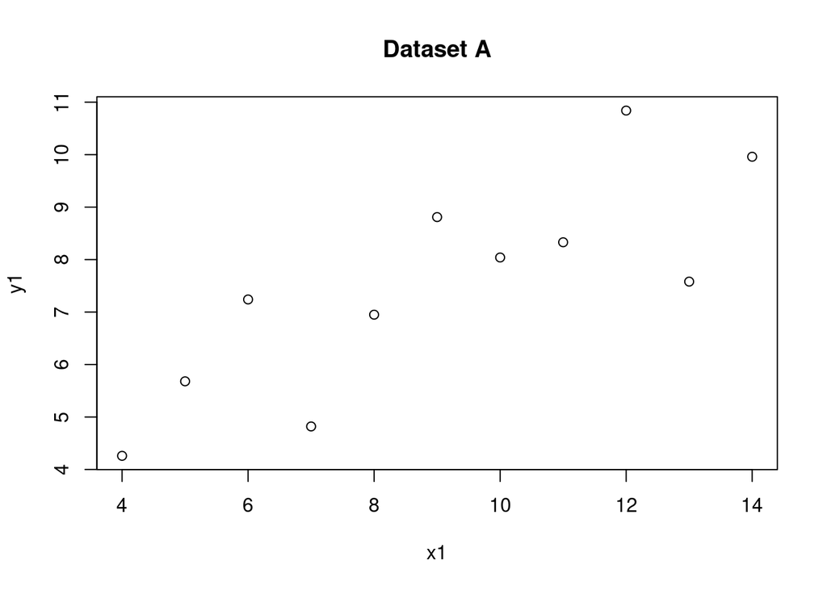

```r
plot(y1 ~ x1, Anscombe, main="Dataset A")
```

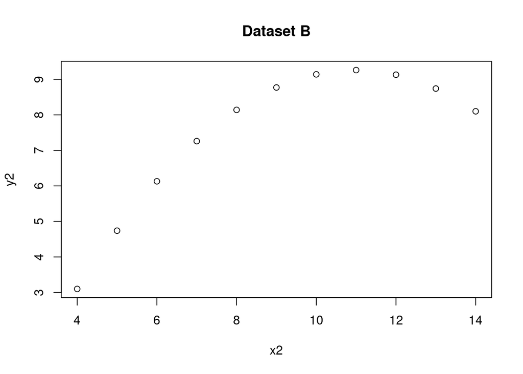

```r
plot(y2 ~ x2, Anscombe, main="Dataset B")
```

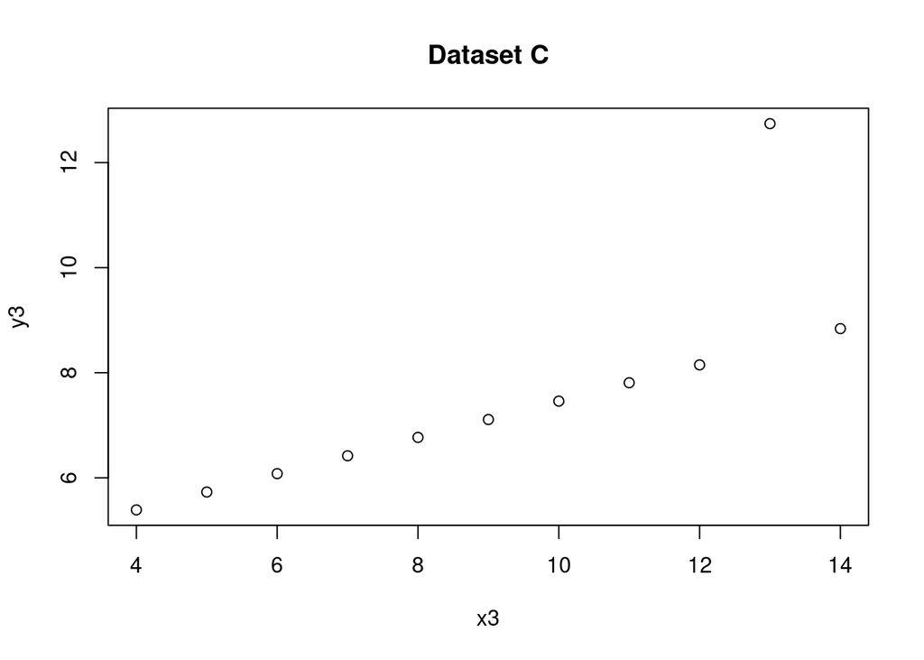

```r
plot(y3 ~ x3, Anscombe, main="Dataset C")
```

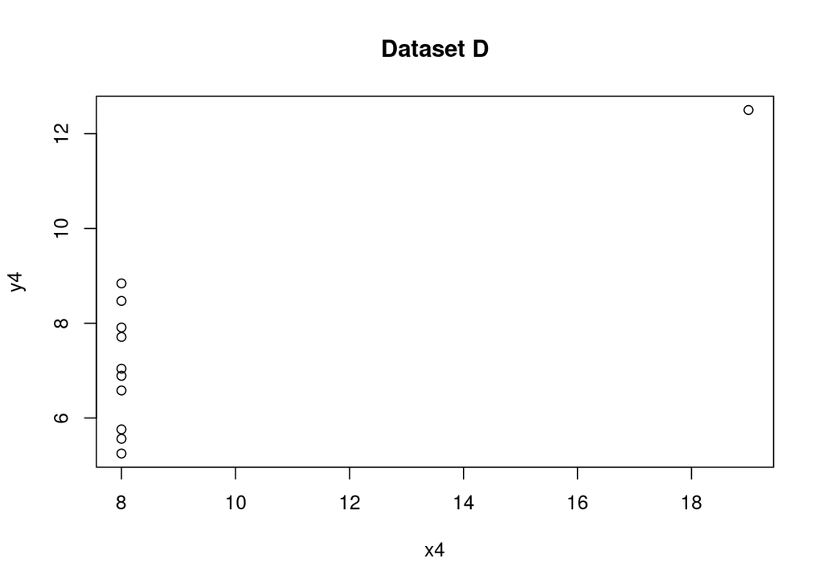

```r
plot(y4 ~ x4, Anscombe, main="Dataset D")
```

## Plots with Best Fit Lines in a Panel

So, first I’ll add a command to make a panel so we can see all the graphs at once. Pretty conveneient.

Next, I createa linear model, using lm(), where we want the y is a function of x (y~x).

Finally, I added a line, abline(), with the coeffients from the linear model, coef().

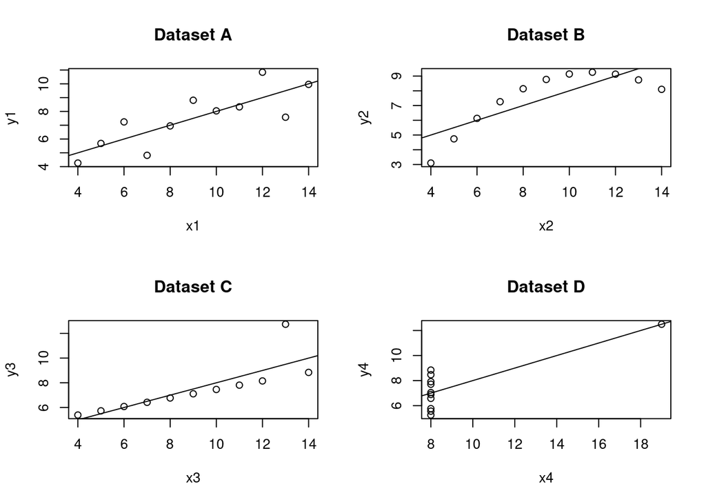

```r
par(mfrow=c(2,2))
plot(y1 ~ x1, Anscombe, main="Dataset A")
  A.lm = lm(y1 ~ x1, Anscombe); abline(coef(A.lm));

plot(y2 ~ x2, Anscombe, main="Dataset B")
  B.lm = lm(y2 ~ x2, Anscombe); abline(coef(B.lm))

plot(y3 ~ x3, Anscombe, main="Dataset C")
  C.lm = lm(y3 ~ x3, Anscombe); abline(coef(C.lm))

plot(y4 ~ x4, Anscombe, main="Dataset D")
  D.lm = lm(y4 ~ x4, Anscombe); abline(coef(D.lm))
```

## Changing the scales so each graph matches

First, I had to determine the minimum and maximum for the Xs and Ys, where plot(y~x, dataframe, xlim=c(min, max).

We need to get separate min for the Xs and Ys and max for the Xs and Ys.

It’s a bit tricky because I had to select several columns…but not the first!

```r
names(Anscombe)
```

```
## [1] "Obs." "x1"   "x2"   "x3"   "x4"   "y1"   "y2"   "y3"   "y4"
```

So, we need columns, 2-5 for the Xs and 6-9 for the Ys. for example, here is the minimum for the Xs.

```r
min(Anscombe[, 2:5])
```

```
## [1] 4
```

So, instead of put this value in each plot command, we can put the to values (min and max) as a vector for each plot function used.

As a trick, it saves sometime, but works when you are a bit further in R, so I’ll show you both ways!

### Manually defining max X and min X and max Y and min Y.

I define a new vector with the mins and maxs. NOTE: I can put to commands on the same line with a semicolon.

```r
xmin = min(Anscombe[, 2:5]); xmin
```

```
## [1] 4
```

```r
xmax = max(Anscombe[, 2:5]); xmax
```

```
## [1] 19
```

```r
ymin = min(Anscombe[, 6:9]); ymin
```

```
## [1] 3.1
```

```r
ymax = max(Anscombe[, 6:9]); ymax
```

```
## [1] 12.74
```

And now the plots. Notice how each plot has the min and max.

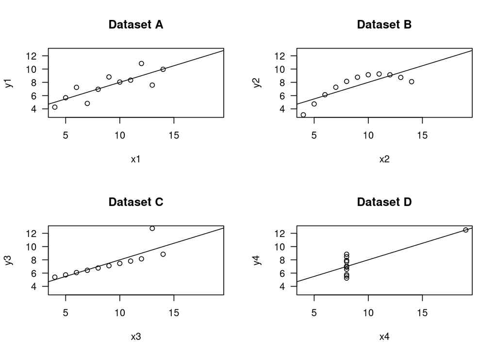

```r
par(mfrow=c(2,2), las=1)
plot(y1 ~ x1, Anscombe, main="Dataset A", xlim=c(4,19), ylim=c(3.1,12.74));
  A.lm = lm(y1 ~ x1, Anscombe); abline(coef(A.lm))

plot(y2 ~ x2, Anscombe, main="Dataset B", xlim=c(4,19), ylim=c(3.1,12.74))
  B.lm = lm(y2 ~ x2, Anscombe); abline(coef(B.lm))

plot(y3 ~ x3, Anscombe, main="Dataset C", xlim=c(4,19), ylim=c(3.1,12.74))
  C.lm = lm(y3 ~ x3, Anscombe); abline(coef(C.lm))

plot(y4 ~ x4, Anscombe, main="Dataset D", xlim=c(4,19), ylim=c(3.1,12.74))
  D.lm = lm(y4 ~ x4, Anscombe); abline(coef(D.lm))
```

I don’t like this method because it relies on me typing the right number – I’d rather define the numbers and then use a vector that contains both the max and min and defined here:

```r
xminmax = c(xmin, xmax); xminmax
```

```
## [1]  4 19
```

```r
yminmax = c(ymin, ymax); yminmax
```

```
## [1]  3.10 12.74
```

Now let’s do the plots, same results!

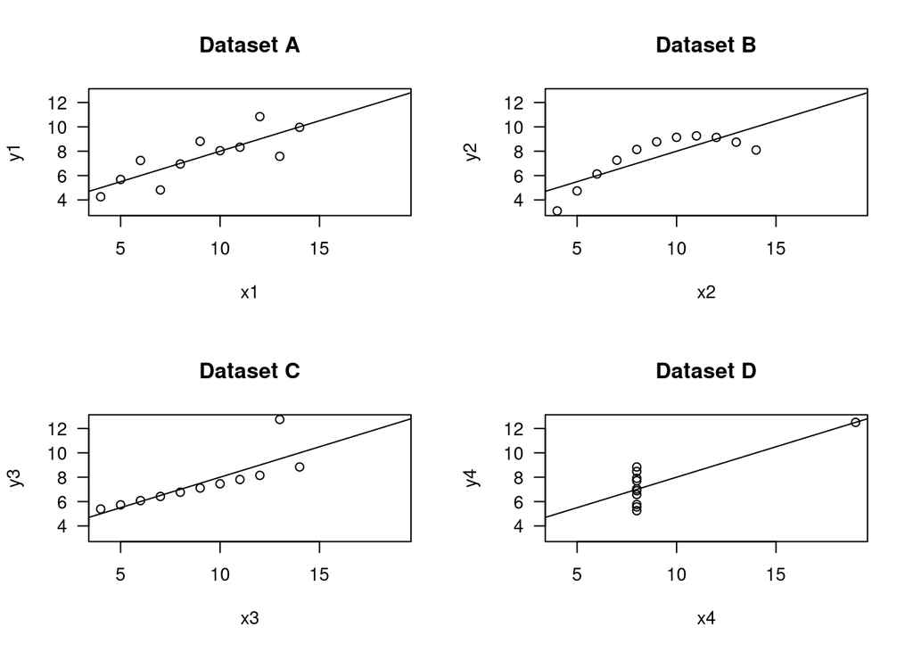

```r
par(mfrow=c(2,2), las=1)
plot(y1 ~ x1, Anscombe, main="Dataset A", xlim=xminmax, ylim=yminmax);
  A.lm = lm(y1 ~ x1, Anscombe); abline(coef(A.lm))

plot(y2 ~ x2, Anscombe, main="Dataset B", xlim=xminmax, ylim=yminmax)
  B.lm = lm(y2 ~ x2, Anscombe); abline(coef(B.lm))

plot(y3 ~ x3, Anscombe, main="Dataset C", xlim=xminmax, ylim=yminmax)
  C.lm = lm(y3 ~ x3, Anscombe); abline(coef(C.lm))

plot(y4 ~ x4, Anscombe, main="Dataset D", xlim=xminmax, ylim=yminmax)
D.lm = lm(y4 ~ x4, Anscombe); abline(coef(D.lm))
```

## Adding Text with the coeficients

Finally, we can add text to the plots using text() and paste() text with a R function, e.g. coef(). I also rounded the values to 3 digits and made the best fit line blue.

NOTE: coef() has two values – slope and intercept!

```r
coef(A.lm)
```

```
## (Intercept)          x1
##   3.0000909   0.5000909
```

We can extract them individually using square brackets

```r
coef(A.lm)[1]
```

```
## (Intercept)
##    3.000091
```

```r
coef(A.lm)[2]
```

```
##        x1
## 0.5000909
```

where position 1 is for the intercept and position 2 is the slope.

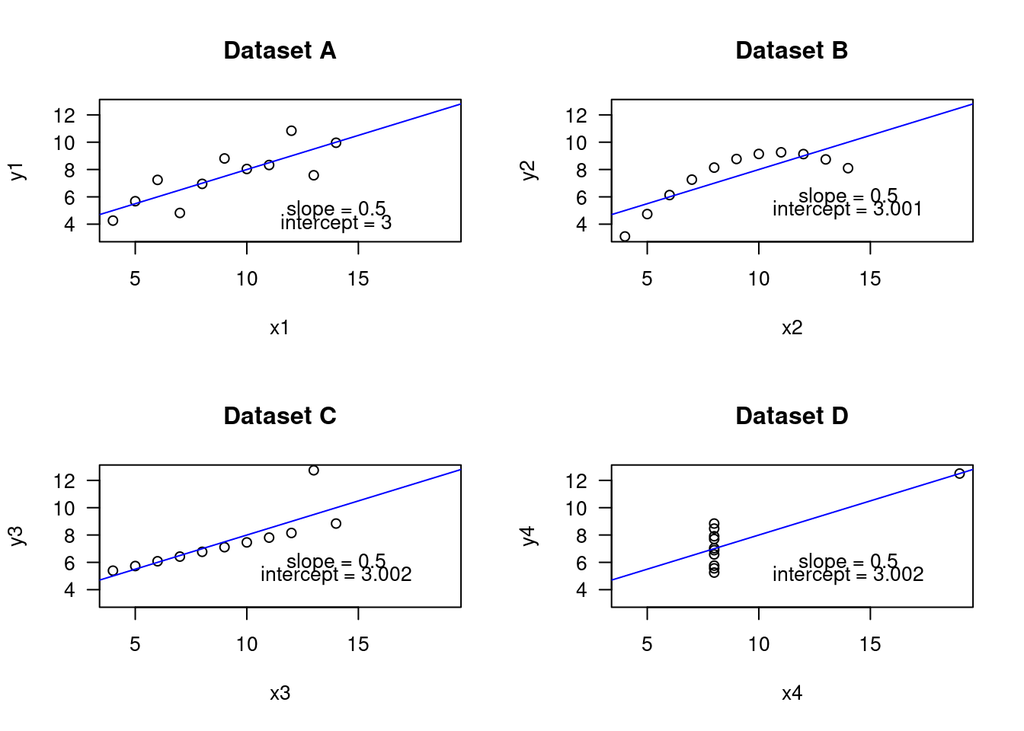

```r
par(mfrow=c(2,2), las=1)
plot(y1 ~ x1, Anscombe, main="Dataset A", xlim=xminmax, ylim=yminmax);
  A.lm = lm(y1 ~ x1, Anscombe); abline(coef(A.lm), col="blue");
  text(14,5, paste("slope =", round(coef(A.lm)[2], 3)));
  text(14,4, paste("intercept =", round(coef(A.lm)[1], 3)))

plot(y2 ~ x2, Anscombe, main="Dataset B", xlim=xminmax, ylim=yminmax);
  B.lm = lm(y2 ~ x2, Anscombe); abline(coef(B.lm), col="blue")
  text(14,6, paste("slope =", round(coef(B.lm)[2], 3)));
  text(14,5, paste("intercept =", round(coef(B.lm)[1], 3)))

plot(y3 ~ x3, Anscombe, main="Dataset C", xlim=xminmax, ylim=yminmax);
  C.lm = lm(y3 ~ x3, Anscombe); abline(coef(C.lm), col="blue")
  text(14,6, paste("slope =", round(coef(C.lm)[2], 3)));
  text(14,5, paste("intercept =", round(coef(C.lm)[1], 3)))

  plot(y4 ~ x4, Anscombe, main="Dataset D", xlim=xminmax, ylim=yminmax);
  D.lm = lm(y4 ~ x4, Anscombe); abline(coef(D.lm), col="blue")
  text(14,6, paste("slope =", round(coef(D.lm)[2], 3)));
  text(14,5, paste("intercept =", round(coef(D.lm)[1], 3)))
```

Can you think of things to make this a better graph? Slack suggestions and I’ll add it!

## Statistics

Are the results signficant? Good question, we can use summary() to get the results:

```r
summary(A.lm)
```

```
##
## Call:
## lm(formula = y1 ~ x1, data = Anscombe)
##
## Residuals:
##      Min       1Q   Median       3Q      Max
## -1.92127 -0.45577 -0.04136  0.70941  1.83882
##
## Coefficients:
##             Estimate Std. Error t value Pr(>|t|)
## (Intercept)   3.0001     1.1247   2.667  0.02573 *
## x1            0.5001     0.1179   4.241  0.00217 **
## ---
## Signif. codes:  0 '***' 0.001 '**' 0.01 '*' 0.05 '.' 0.1 ' ' 1
##
## Residual standard error: 1.237 on 9 degrees of freedom
## Multiple R-squared:  0.6665, Adjusted R-squared:  0.6295
## F-statistic: 17.99 on 1 and 9 DF,  p-value: 0.00217
```

```r
summary(B.lm)
```

```
##
## Call:
## lm(formula = y2 ~ x2, data = Anscombe)
##
## Residuals:
##     Min      1Q  Median      3Q     Max
## -1.9009 -0.7609  0.1291  0.9491  1.2691
##
## Coefficients:
##             Estimate Std. Error t value Pr(>|t|)
## (Intercept)    3.001      1.125   2.667  0.02576 *
## x2             0.500      0.118   4.239  0.00218 **
## ---
## Signif. codes:  0 '***' 0.001 '**' 0.01 '*' 0.05 '.' 0.1 ' ' 1
##
## Residual standard error: 1.237 on 9 degrees of freedom
## Multiple R-squared:  0.6662, Adjusted R-squared:  0.6292
## F-statistic: 17.97 on 1 and 9 DF,  p-value: 0.002179
```

```r
summary(C.lm)
```

```
##
## Call:
## lm(formula = y3 ~ x3, data = Anscombe)
##
## Residuals:
##     Min      1Q  Median      3Q     Max
## -1.1586 -0.6146 -0.2303  0.1540  3.2411
##
## Coefficients:
##             Estimate Std. Error t value Pr(>|t|)
## (Intercept)   3.0025     1.1245   2.670  0.02562 *
## x3            0.4997     0.1179   4.239  0.00218 **
## ---
## Signif. codes:  0 '***' 0.001 '**' 0.01 '*' 0.05 '.' 0.1 ' ' 1
##
## Residual standard error: 1.236 on 9 degrees of freedom
## Multiple R-squared:  0.6663, Adjusted R-squared:  0.6292
## F-statistic: 17.97 on 1 and 9 DF,  p-value: 0.002176
```

```r
summary(D.lm)
```

```
##
## Call:
## lm(formula = y4 ~ x4, data = Anscombe)
##
## Residuals:
##    Min     1Q Median     3Q    Max
## -1.751 -0.831  0.000  0.809  1.839
##
## Coefficients:
##             Estimate Std. Error t value Pr(>|t|)
## (Intercept)   3.0017     1.1239   2.671  0.02559 *
## x4            0.4999     0.1178   4.243  0.00216 **
## ---
## Signif. codes:  0 '***' 0.001 '**' 0.01 '*' 0.05 '.' 0.1 ' ' 1
##
## Residual standard error: 1.236 on 9 degrees of freedom
## Multiple R-squared:  0.6667, Adjusted R-squared:  0.6297
## F-statistic:    18 on 1 and 9 DF,  p-value: 0.002165
```

From this we can determine if the model is outside the range of random variation.

I each case the p-values are <0.05, suggesting significant. In addition, we can look at the R2, which is an estimate of how much of the variation of y is explained by x. In nearly every case these value are above .62, which is generally thought of as quite good as a predictor. Not perfect, which would be 1, but not close to zero, where there would be not explanatory value of x.

## What’s going on!

We need to look at the assumptions, which relies on plots() of the linear model – which generates 4 default plots.

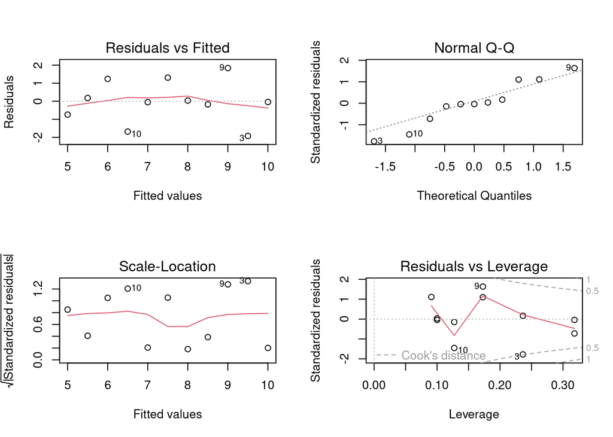

```r
par(mfrow=c(2,2)); plot(A.lm); par(mfrow=c(1,1))
```

Let’s compare each model with their assumptions. There should be no structure in first diagnostic plot!

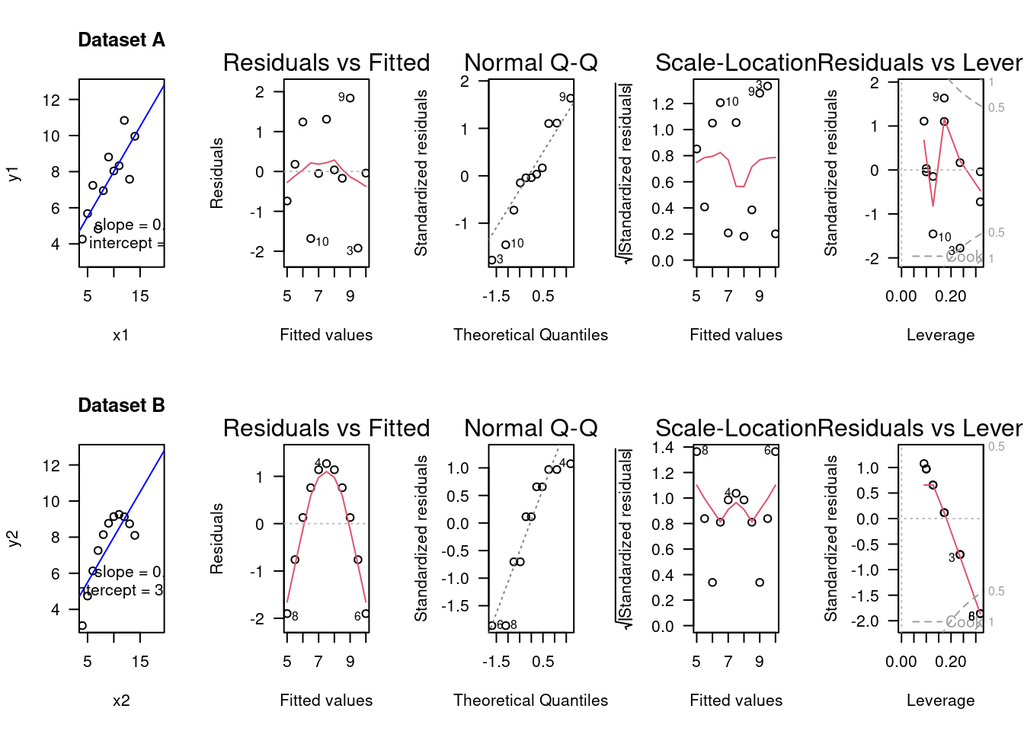

```r
par(mfrow=c(2,5), las=1)
plot(y1 ~ x1, Anscombe, main="Dataset A", xlim=xminmax, ylim=yminmax);
  A.lm = lm(y1 ~ x1, Anscombe); abline(coef(A.lm), col="blue");
  text(14,5, paste("slope =", round(coef(A.lm)[2], 3)));
  text(14,4, paste("intercept =", round(coef(A.lm)[1], 3)))

plot(A.lm)

plot(y2 ~ x2, Anscombe, main="Dataset B", xlim=xminmax, ylim=yminmax);
  B.lm = lm(y2 ~ x2, Anscombe); abline(coef(B.lm), col="blue")
  text(14,6, paste("slope =", round(coef(B.lm)[2], 3)));
  text(14,5, paste("intercept =", round(coef(B.lm)[1], 3)))

plot(B.lm)
```

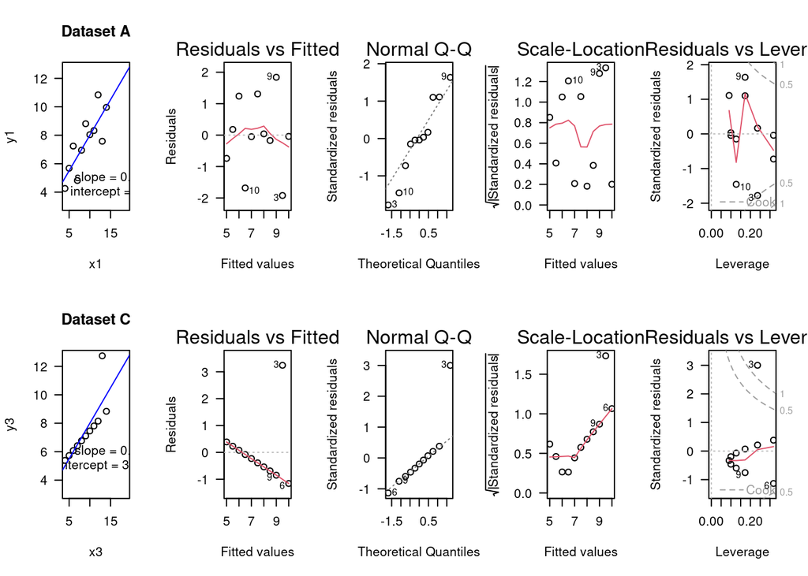

```r
par(mfrow=c(2,5), las=1)
plot(y1 ~ x1, Anscombe, main="Dataset A", xlim=xminmax, ylim=yminmax);
  A.lm = lm(y1 ~ x1, Anscombe); abline(coef(A.lm), col="blue");
  text(14,5, paste("slope =", round(coef(A.lm)[2], 3)));
  text(14,4, paste("intercept =", round(coef(A.lm)[1], 3)))

plot(A.lm)

plot(y3 ~ x3, Anscombe, main="Dataset C", xlim=xminmax, ylim=yminmax);
  C.lm = lm(y3 ~ x3, Anscombe); abline(coef(C.lm), col="blue")
  text(14,6, paste("slope =", round(coef(C.lm)[2], 3)));
  text(14,5, paste("intercept =", round(coef(C.lm)[1], 3)))

plot(C.lm)
```

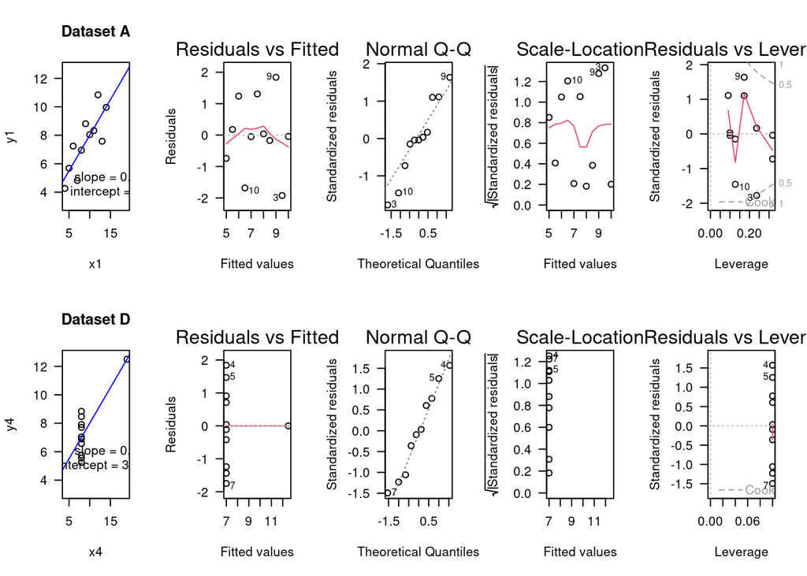

```r
par(mfrow=c(2,5), las=1)
plot(y1 ~ x1, Anscombe, main="Dataset A", xlim=xminmax, ylim=yminmax);
  A.lm = lm(y1 ~ x1, Anscombe); abline(coef(A.lm), col="blue");
  text(14,5, paste("slope =", round(coef(A.lm)[2], 3)));
  text(14,4, paste("intercept =", round(coef(A.lm)[1], 3)))

plot(A.lm)

plot(y4 ~ x4, Anscombe, main="Dataset D", xlim=xminmax, ylim=yminmax);
  D.lm = lm(y4 ~ x4, Anscombe); abline(coef(D.lm), col="blue")
  text(14,6, paste("slope =", round(coef(D.lm)[2], 3)));
  text(14,5, paste("intercept =", round(coef(D.lm)[1], 3)))

plot(D.lm)
```